# Kaggle - Titanic

Saurabh Sindwani

23 May 2017

# Synopsis

The goal is to predict titanic survivors from a dataset that features the passenger’s class, name, sex, age, number of siblings/spouses aboard, number of parents/child aboard, ticket number, fare, and the embarking port. This report provides data exploration with exploratory visualizations, feature engineering and predictive modeling.

# Data Exploration

### Data Loading

- Load Data and replace missing data with “NA”" values.

```r
# Load the training data set, add NA to missing(blank) values
train <- read.csv("./data/train.csv", header=T, na.strings = c(""))
test <- read.csv("./data/test.csv", header=T, na.strings = c(""))
str(train)
```

```
## 'data.frame':    891 obs. of  12 variables:
##  $ PassengerId: int  1 2 3 4 5 6 7 8 9 10 ...
##  $ Survived   : int  0 1 1 1 0 0 0 0 1 1 ...
##  $ Pclass     : int  3 1 3 1 3 3 1 3 3 2 ...
##  $ Name       : Factor w/ 891 levels "Abbing, Mr. Anthony",..: 109 191 358 277 16 559 520 629 417 581 ...
##  $ Sex        : Factor w/ 2 levels "female","male": 2 1 1 1 2 2 2 2 1 1 ...
##  $ Age        : num  22 38 26 35 35 NA 54 2 27 14 ...
##  $ SibSp      : int  1 1 0 1 0 0 0 3 0 1 ...
##  $ Parch      : int  0 0 0 0 0 0 0 1 2 0 ...
##  $ Ticket     : Factor w/ 681 levels "110152","110413",..: 524 597 670 50 473 276 86 396 345 133 ...
##  $ Fare       : num  7.25 71.28 7.92 53.1 8.05 ...
##  $ Cabin      : Factor w/ 147 levels "A10","A14","A16",..: NA 82 NA 56 NA NA 130 NA NA NA ...
##  $ Embarked   : Factor w/ 3 levels "C","Q","S": 3 1 3 3 3 2 3 3 3 1 ...
```

### Survived

How many Survived?

```r
library(ggplot2)
table(train$Survived)
```

```
##
##   0   1
## 549 342
```

```r
prop.table(table(train$Survived))
```

```
##
##         0         1
## 0.6161616 0.3838384
```

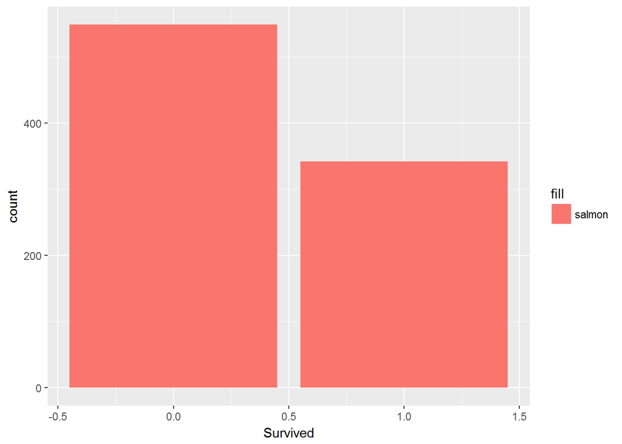

```r
ggplot(train, aes(Survived, fill="salmon")) + geom_bar()
```

Survival rate is 38% while those who did not make it is 62%.

### Class

There are a few things money cannot buy like manners, morals, intelligence and CLASS. But, class could be bought on Titanic!

```r
train$Pclass <- as.factor(train$Pclass)
table(train$Pclass)
```

```
##
##   1   2   3
## 216 184 491
```

Most people travelled 3rd class and as the chart depicts most of them did not make it. Clearly, disadvantage class 3.

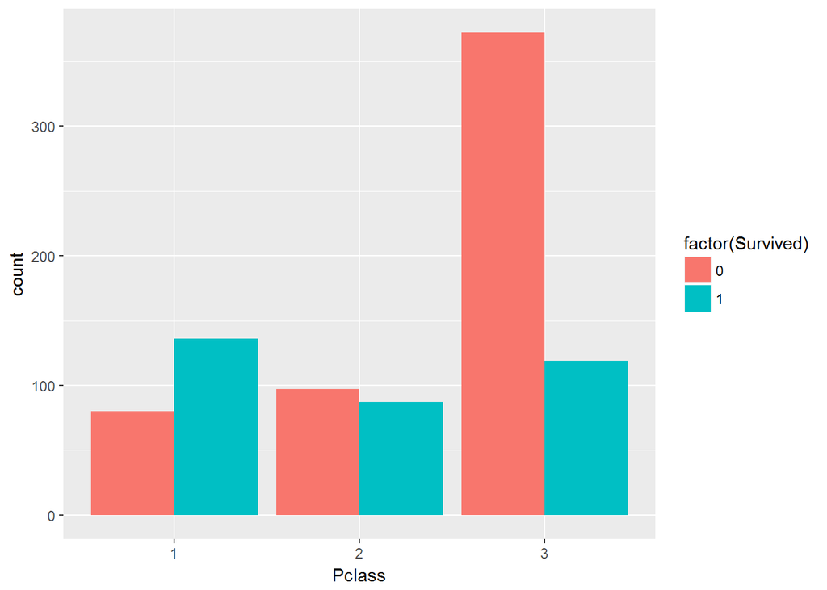

```r
ggplot(train, aes(Pclass, ..count.., fill = factor(Survived))) + geom_bar(position="dodge")
```

### Name

What’s in the name? Mostly, Mr., Mrs., Miss and Master and then a few interesting others. The survival rates differ by title, advantage Ladies and children!

```r
library(stringr)
Title <- as.factor(str_sub(train$Name, str_locate(train$Name, ",")[ , 1] + 2, str_locate(train$Name, "\\.")[ , 1] - 1))
table(train$Sex,Title)
```

```
##         Title
##          Capt Col Don  Dr Jonkheer Lady Major Master Miss Mlle Mme  Mr Mrs
##   female    0   0   0   1        0    1     0      0  182    2   1   0 125
##   male      1   2   1   6        1    0     2     40    0    0   0 517   0
##         Title
##           Ms Rev Sir the Countess
##   female   1   0   0            1
##   male     0   6   1            0
```

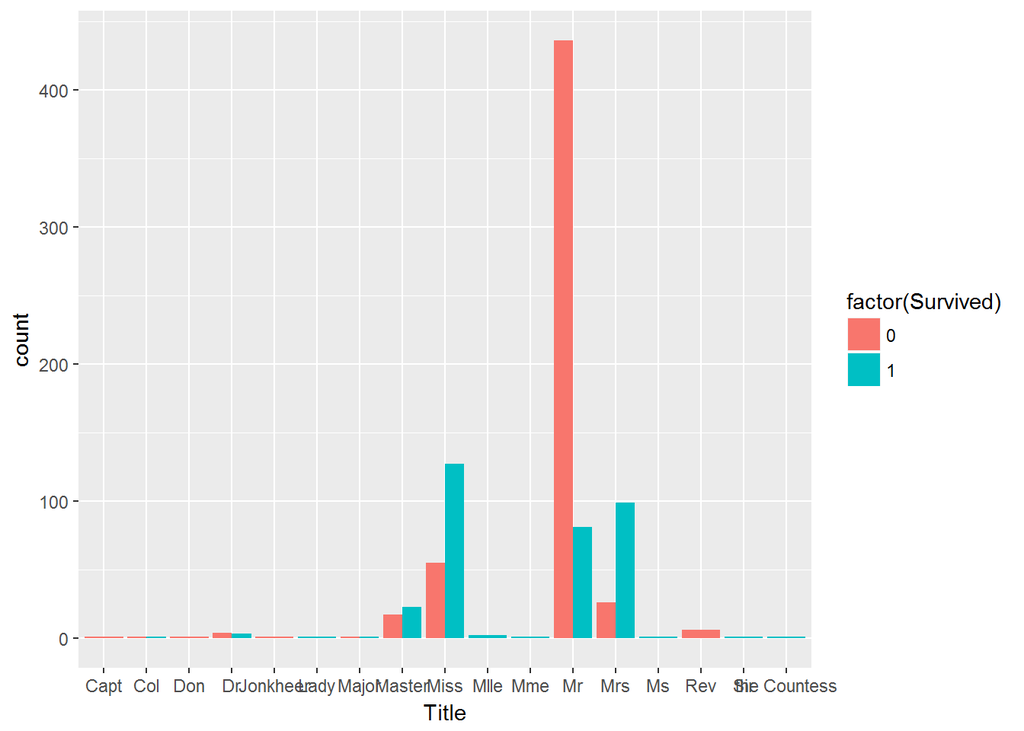

```r
ggplot(train, aes(Title, ..count.., fill = factor(Survived))) + geom_bar(position="dodge")
```

```r
NameLength <- nchar(as.character(train$Name))
NameLenCat<-cut(NameLength, seq(12,82,5))
table(train$Survived, NameLenCat)
```

```
##    NameLenCat
##     (12,17] (17,22] (22,27] (27,32] (32,37] (37,42] (42,47] (47,52]
##   0      69     170     162      92      23      18       9       1
##   1      19      61      74      73      31      20      31      22
##    NameLenCat
##     (52,57] (57,62] (62,67] (67,72] (72,77] (77,82]
##   0       4       0       0       0       0       0
##   1       6       1       2       0       0       1
```

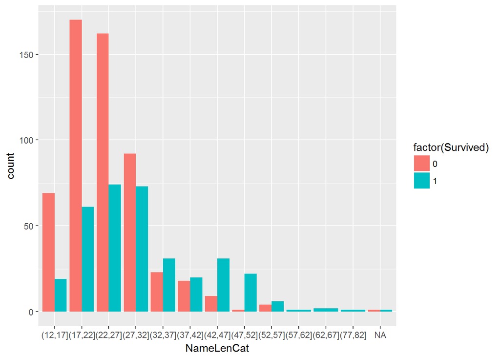

```r
ggplot(train, aes(NameLenCat, ..count.., fill = factor(Survived))) + geom_bar(position="dodge")
```

Longer names help you survive!! Strange but true on titanic!

### Sex

Too many men when compared to women. Clearly, women first!

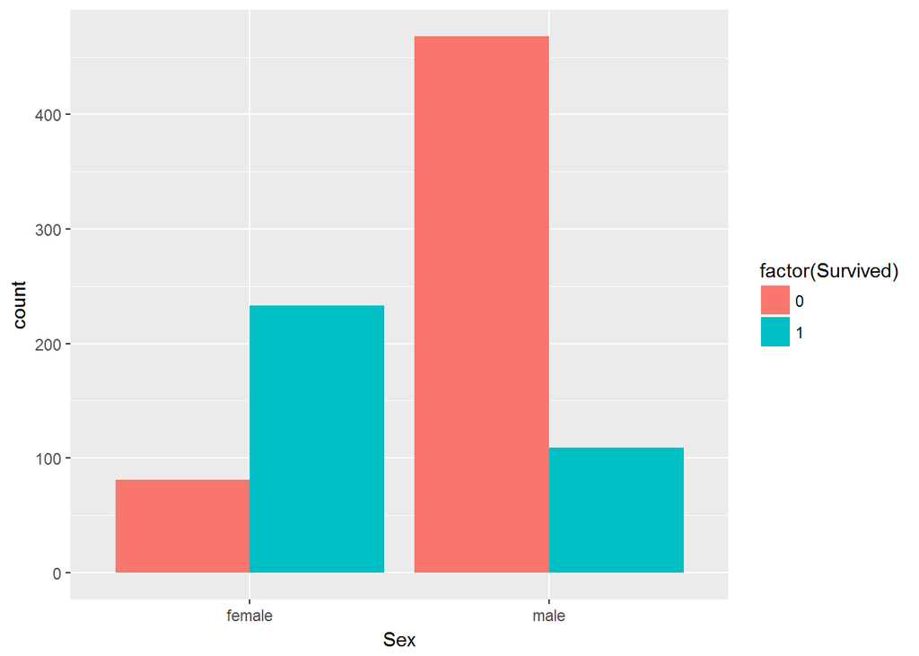

```r
ggplot(train, aes(Sex, ..count.., fill = factor(Survived))) + geom_bar(position="dodge")
```

### Age

Too many missing values (177/891 = 20%), will need to impute.

```r
summary(train$Age)
```

```
##    Min. 1st Qu.  Median    Mean 3rd Qu.    Max.    NA's
##    0.42   20.12   28.00   29.70   38.00   80.00     177
```

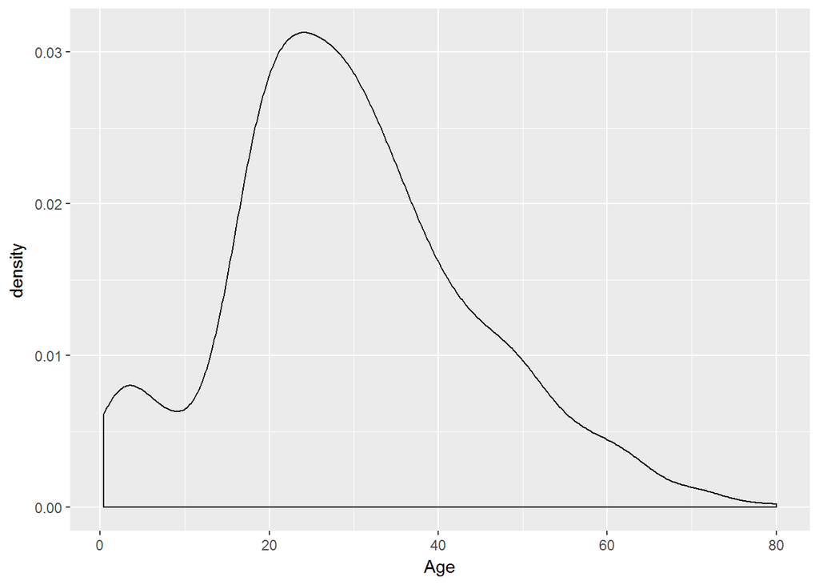

```r
ggplot(train, aes(Age)) + geom_density(kernel="gaussian")
```

```r
table(train$Survived, is.na(train$Age))
```

```
##
##     FALSE TRUE
##   0   424  125
##   1   290   52
```

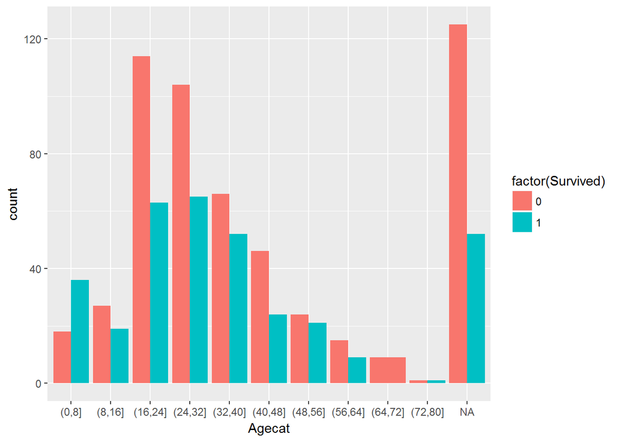

```r
Age_Null <- is.na(train$Age)
Agecat<-cut(train$Age, seq(0,85,8))
ggplot(train, aes(Agecat, ..count.., fill = factor(Survived))) + geom_bar(position="dodge")
```

Passengers with age missing have a survival rate of 29% while others have a survival rate of 40%. Differing age categories have different survival rate, this will help the predictions.

### Sibling or Spouse

608 travelling alone, rest with family. Travelling Single proved to be disadvantageous; while travalling with 1 is advantageous.

```r
table(train$SibSp)
```

```
##
##   0   1   2   3   4   5   8
## 608 209  28  16  18   5   7
```

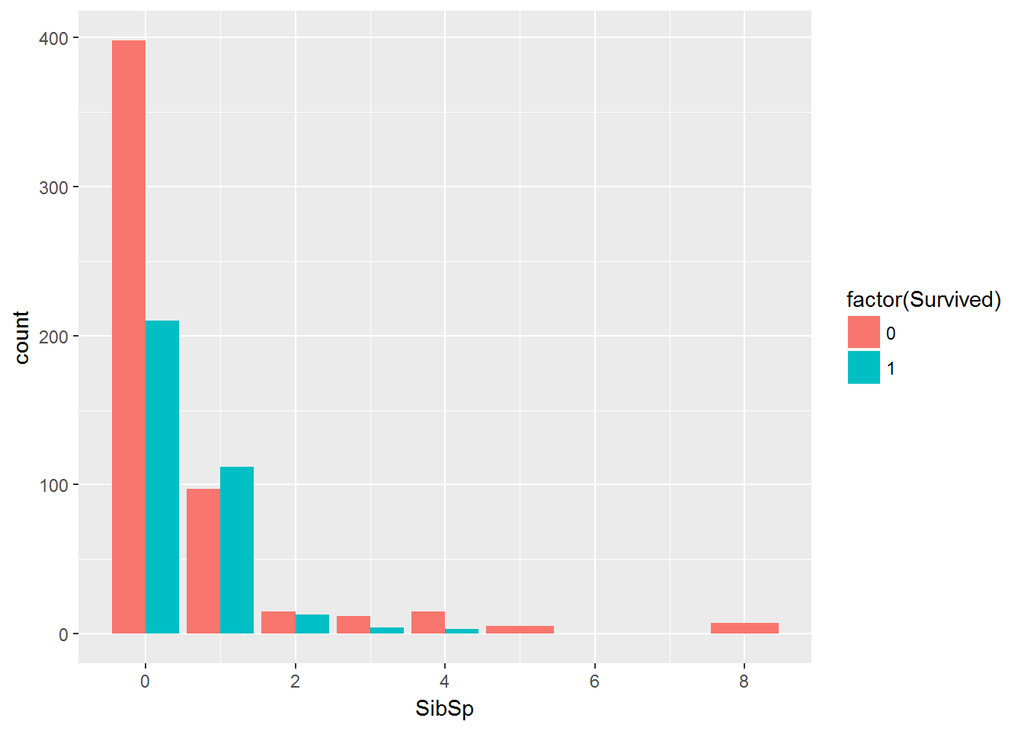

```r
ggplot(train, aes(SibSp, ..count.., fill = factor(Survived))) + geom_bar(position="dodge")
```

### Parent or Child

678 travelling alone, rest with family. Again, travelling Single proved to be disadvantageous; while travalling with 1,2,3 is advantageous.

```r
table(train$Parch)
```

```
##
##   0   1   2   3   4   5   6
## 678 118  80   5   4   5   1
```

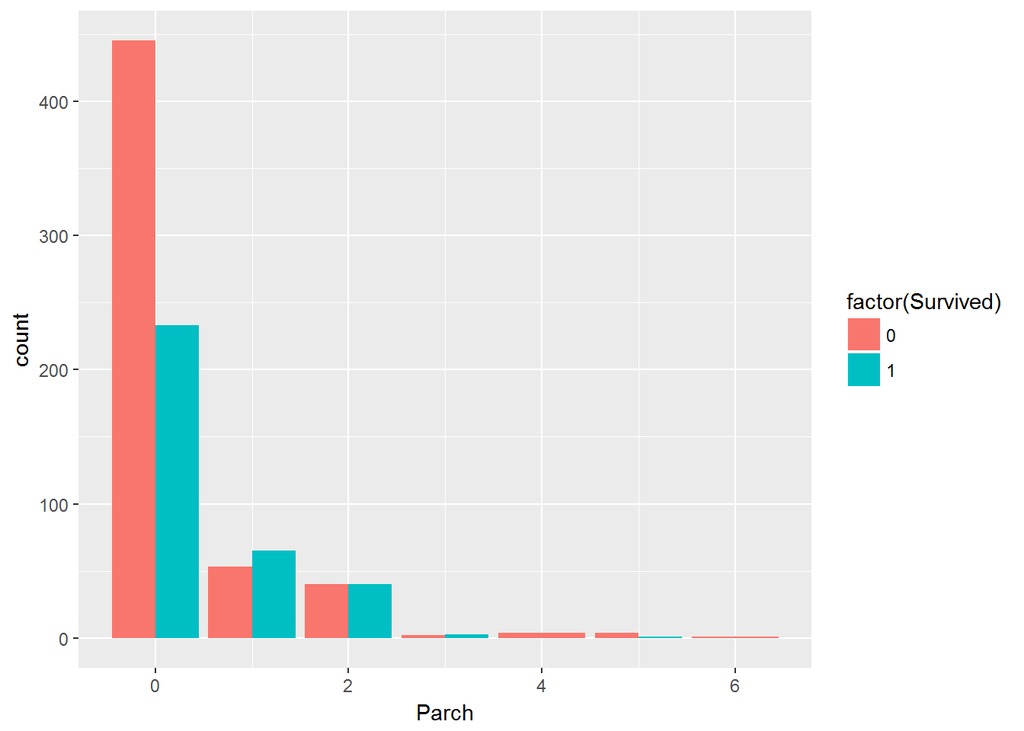

```r
ggplot(train, aes(Parch, ..count.., fill = factor(Survived))) + geom_bar(position="dodge")
```

### Ticket

There are tickets with differing total number of digits and there are tickets that start with characters. Does that encode some information? Some ticket types like those starting with 1, 2 and P have higher chances of survival.

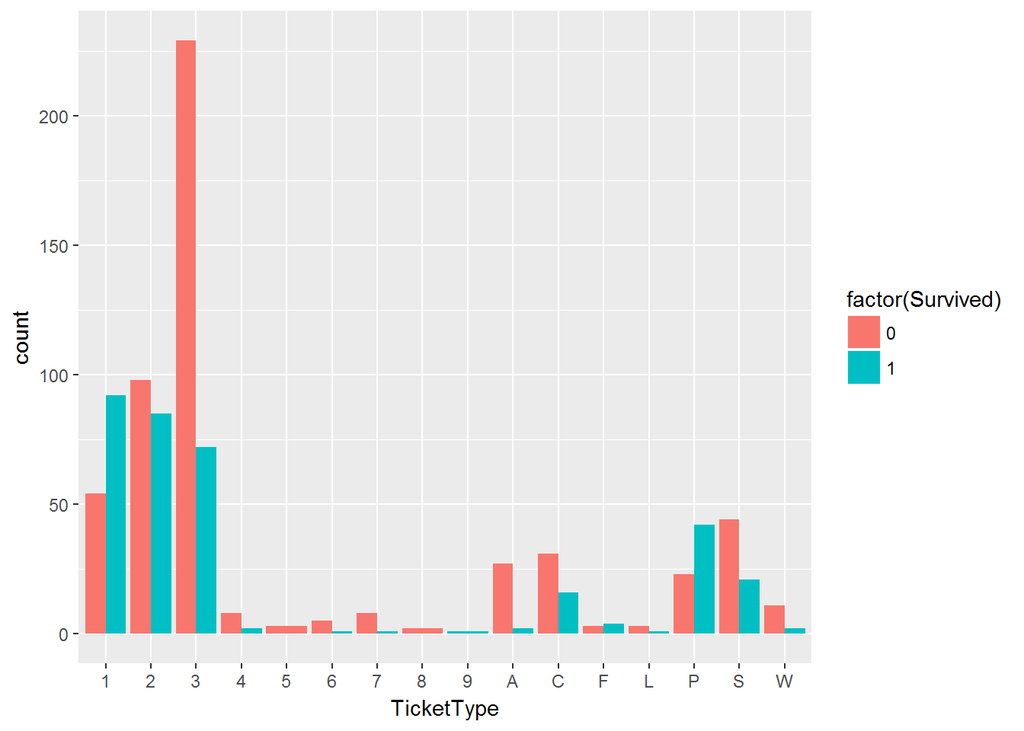

```r
TicketType <- substring(train$Ticket,1,1)
TicketType2 <- nchar(as.character(train$Ticket))
TicketType <- as.factor(TicketType)
TicketType2 <- as.factor(TicketType2)
ggplot(train, aes(TicketType, ..count.., fill = factor(Survived))) + geom_bar(position="dodge")
```

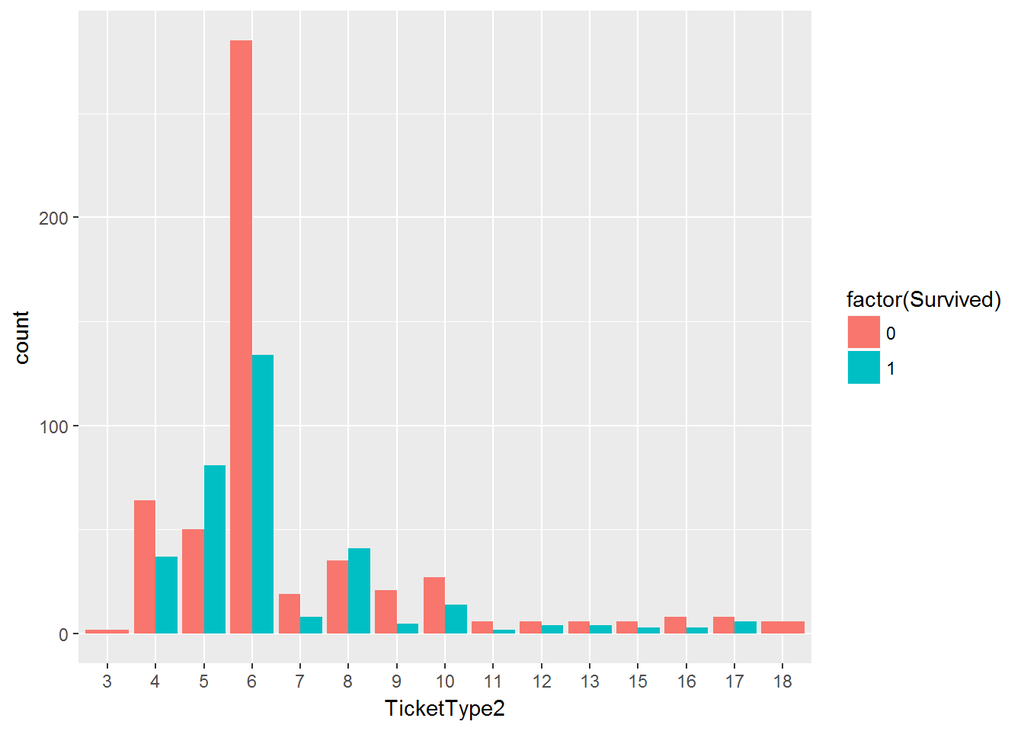

```r
ggplot(train, aes(TicketType2, ..count.., fill = factor(Survived))) + geom_bar(position="dodge")
```

### Fare

There are 248 unique fares. As expected, 1st class is way more expensive.

```r
length(unique(train$Fare))
```

```
## [1] 248
```

```r
aggregate(Fare ~ Pclass, train, mean)
```

```
##   Pclass     Fare
## 1      1 84.15469
## 2      2 20.66218
## 3      3 13.67555
```

### Cabin

There are only 204 cabin values, out of 204 there are 148 unique values. There are 687 missing values.

```r
library(DT)
sum(!is.na(train$Cabin))
```

```
## [1] 204
```

```r
length(unique(train$Cabin))
```

```
## [1] 148
```

```r
sum(is.na(train$Cabin))
```

```
## [1] 687
```

```r
datatable(data.frame(summary(train$Cabin)))
```

|  | summary.train.Cabin. |
| --- | --- |
| B96 B98 | 4 |
| C23 C25 C27 | 4 |
| G6 | 4 |
| C22 C26 | 3 |
| D | 3 |
| E101 | 3 |
| F2 | 3 |
| F33 | 3 |
| B18 | 2 |
| B20 | 2 |

[output cut: 90 more lines]

Clearly, those with cabins have higher survival rates.

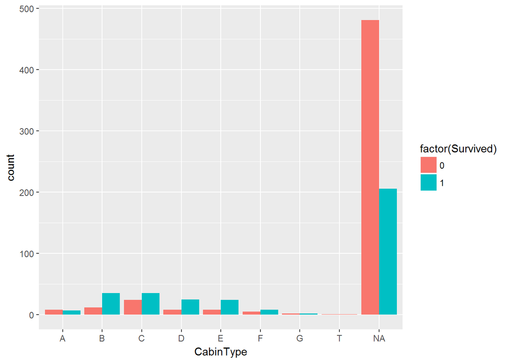

```r
CabinType <-  substring(train$Cabin,1,1)
ggplot(train, aes(CabinType, ..count.., fill = factor(Survived))) + geom_bar(position="dodge")
```

### Embarked

There are 3 departure locations, most people are from Southampton then Cherbourg and Queenstown. There are 2 missing values for embarking point which need to be imputed. Cherbourg has the highest survival rate as mostly class 1 boarded from there.

```r
table(train$Embarked)
```

```
##
##   C   Q   S
## 168  77 644
```

```r
datatable(train[is.na(train$Embarked),])
```

|  | PassengerId | Survived | Pclass | Name | Sex | Age | SibSp | Parch | Ticket | Fare | Cabin | Embarked |
| --- | --- | --- | --- | --- | --- | --- | --- | --- | --- | --- | --- | --- |
| 62 | 62 | 1 | 1 | Icard, Miss. Amelie | female | 38 | 0 | 0 | 113572 | 80 | B28 |  |
| 830 | 830 | 1 | 1 | Stone, Mrs. George Nelson (Martha Evelyn) | female | 62 | 0 | 0 | 113572 | 80 | B28 |  |

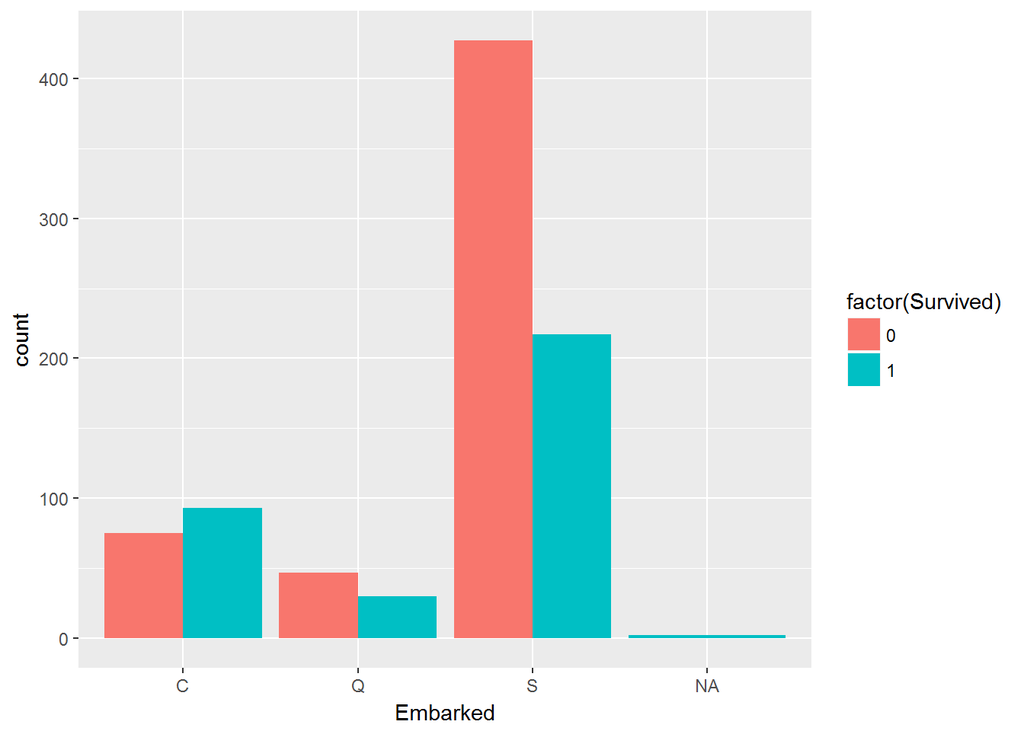

```r
ggplot(train, aes(Embarked, ..count.., fill = factor(Survived))) + geom_bar(position="dodge")
```

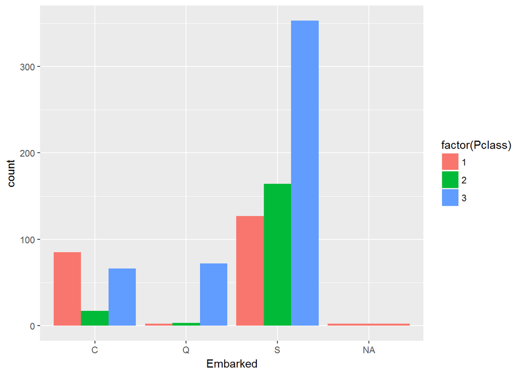

```r
ggplot(train, aes(Embarked, ..count.., fill = factor(Pclass))) + geom_bar(position="dodge")
```

# Feature Engineering

### Combining Data Sets

```r
Survived <- train$Survived
train$Survived <- NULL
combi <- rbind(train,test)
```

### New Features

Based on the insights gained from the data exploration above, we create new features.

- Title: Extract title from the name
- NameLenCat: Formulate categories based on the length of the names
- Family Size: Total of Siblings/Spouse and Parent/Child
- Ticket Letter: First Letter of the ticket
- Ticket Length: Length of the ticket number
- Cabin Type : First letter of cabin, replace NA with “N”

```r
#Title
combi$Title <- as.factor(str_sub(combi$Name, str_locate(combi$Name, ",")[ , 1] + 2, str_locate(combi$Name, "\\.")[ , 1] - 1))

#Name Length Category
c_NameLength <- nchar(as.character(combi$Name))
combi$NameLenCat<-cut(c_NameLength, seq(11,86,5))

#Family Size
combi$FamilySize<- combi$SibSp + combi$Parch + 1

#Ticket First Letter
combi$TicketLett <- as.factor(substring(combi$Ticket,1,1))
#Ticket Length
combi$TicketLen <- as.factor(nchar(as.character(combi$Ticket)))

#CabinType
combi$CabinType <-  substring(combi$Cabin,1,1)
combi$CabinType[is.na(combi$CabinType)] <- "N"
combi$CabinType <- as.factor(combi$CabinType)
```

### Impute missing values

- Embarked: Replace 2 missing values with “S”" which is most occuring value by a big margin.
- Fare: Replace 1 missing value with the mean on certain conditions.
- Age: There are too many missing values, impute Using rpart.

```r
combi$Embarked[is.na(combi$Embarked)] <- "S"
combi$Fare[is.na(combi$Fare)] <-mean(combi[combi$Pclass == 3 & combi$Embarked == "S" & combi$TicketLen==4 &
                                                   combi$CabinType == "N", "Fare"], na.rm = TRUE)

library(rpart)
Agefit <- rpart(Age ~ Pclass + Sex + SibSp + Parch + Fare + Embarked + Title + NameLenCat +FamilySize +
                        TicketLett+TicketLen+CabinType, data=combi[!is.na(combi$Age),], method="anova")
combi$Age[is.na(combi$Age)] <- predict(Agefit, combi[is.na(combi$Age),])
```

Seperate the data into train and test sets

```r
train <- cbind(Survived, combi[1:nrow(train),c(2,4,5,6,7,9,11,12,13,14,15,16,17)])
test <- combi[(nrow(train)+1):nrow(combi),c(2,4,5,6,7,9,11,12,13,14,15,16,17)]
```

# Build Random Forest Ensemble

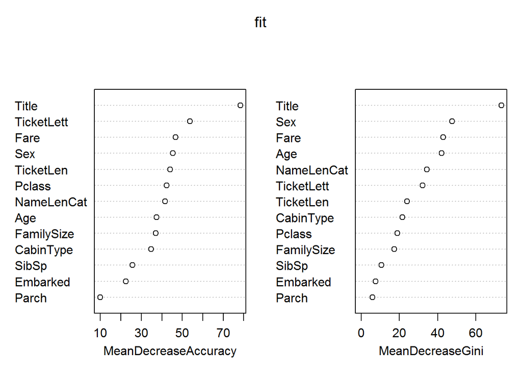

```r
library(randomForest)
set.seed(777)
fit <- randomForest(as.factor(Survived) ~  Pclass + Sex + Age + SibSp + Parch + Fare + Embarked + Title + NameLenCat +FamilySize
                    + TicketLett + TicketLen + CabinType, data=train, importance=TRUE, ntree=2000)
# Look at variable importance
varImpPlot(fit)
```

```r
# Now let's make a prediction and write a submission file
Prediction <- predict(fit, test)
submit <- data.frame(PassengerId = c(892:1309), Survived = Prediction)
write.csv(submit, file = "randomforest.csv", row.names = FALSE)
```

A few other tweaks in the features and models took me to 0.81340 - top 5% at the time of writing this!